## title: “Assignment STAT702”

**Group 5**: Hitarth Asrani and Genevieve Connell

**Product name**: BIC Round Stic Xtra Life Ballpoint Pen, Medium Point (1.0mm), Red, 12-Count

**Reviews asin**: B00006IE7J

# 1 Analysis of Sales Data

## 1(a) For the product (sku_id) which has been assigned to your group (see page 6), compute the total monthly sales from January 2011 – July 2013. Present your results in an appropriate plot and write 2 – 3 sentences describing your results.

Hint: This will require some “wrangling” of the variable week. To do this, format week as a date and then use the appropriate lubridate function to extract the month.

Marking Criteria

- Total monthly sales have been correctly computed and are displayed in an appropriate plot.
- Description of results/plot is correct and provides useful insights.
- Plot is constructed using ggplot2 and has appropriate titles, labels, scales etc.**

## Answer

From Jan 2011 - July 2013, 98434 units of sku 219844 were sold with a mean monthly sale of 3175.3 and an interquartile range of 2621.5 - 3301.5.

Monthly sales are plotted below, no trend or seasonal pattern is evident in this plot. There are three months with significantly high sales, May 2011, December 2011 and January 2012. The most significant outlier was in January 2012 when 8871 units were sold. As shown in the plots below these high monthly sales correspond with a high proportion of stores featuring and/or displaying the product.

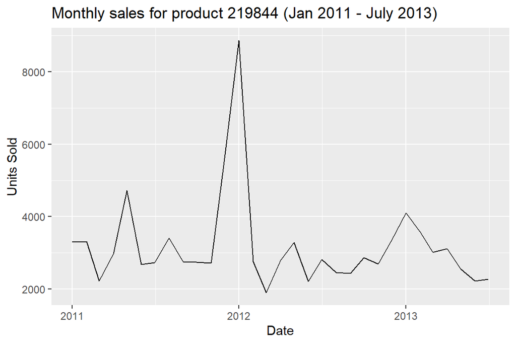

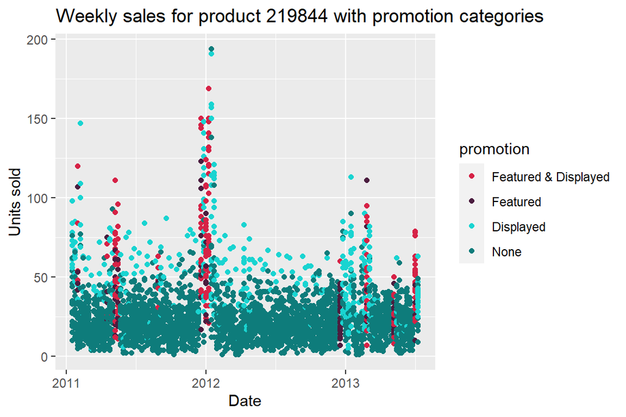

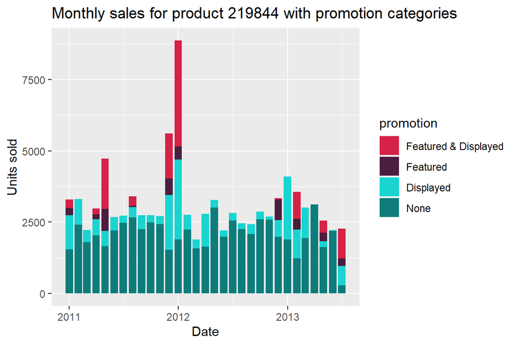

## 1(b) The GM Sales wants to know which stores are performing well and which are not, in terms of product sales. For the product (sku_id) which has been assigned to your group, use appropriate summary statistics and plots to investigate sales performance across the stores and write 2 – 3 paragraphs summarising your findings.

Hint: You will need to decide what it means for a store to be “performing well” and how you will evaluate this using the data.

Marking criteria

- Sales performance is clearly defined.
- Written summary includes relevant and appropriate summary statistics and plots.
- Plot/s are constructed using ggplot2 and have appropriate titles, labels, scales etc.
- Descriptions of results and plots are correct and provides useful insights.

## Answer

All stores have been ranked based on their total sales from Jan 2011 to July 2013. The store with the highest total units sold is ranked ‘1’, this is store 9279 with 6698 units.

Below is a bar chart showing the total units sold with stores ordered by rank. Sales for 2013 are much lower than 2011 and 2012 as only half the years data is included.

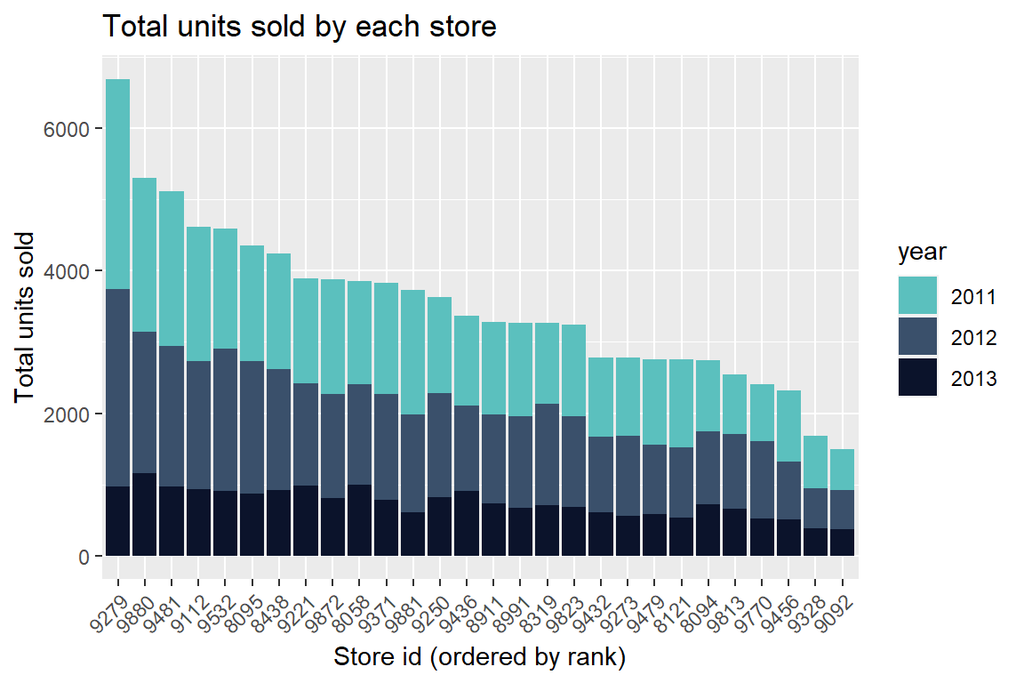

For a more detailed look at store performance monthly sales have been plotted for each store and categorised as ‘High’, ‘Average’ or ‘Low’ performing. These categories are based on the interquartile range for monthly sales. This range is 71 - 138 and captures 50% of all monthly sales. Monthly sales within the range are classified as ‘Average’, sales greater than 138 are classified as ‘High’ performing and those below 71 are classified as ‘Low’ performing.

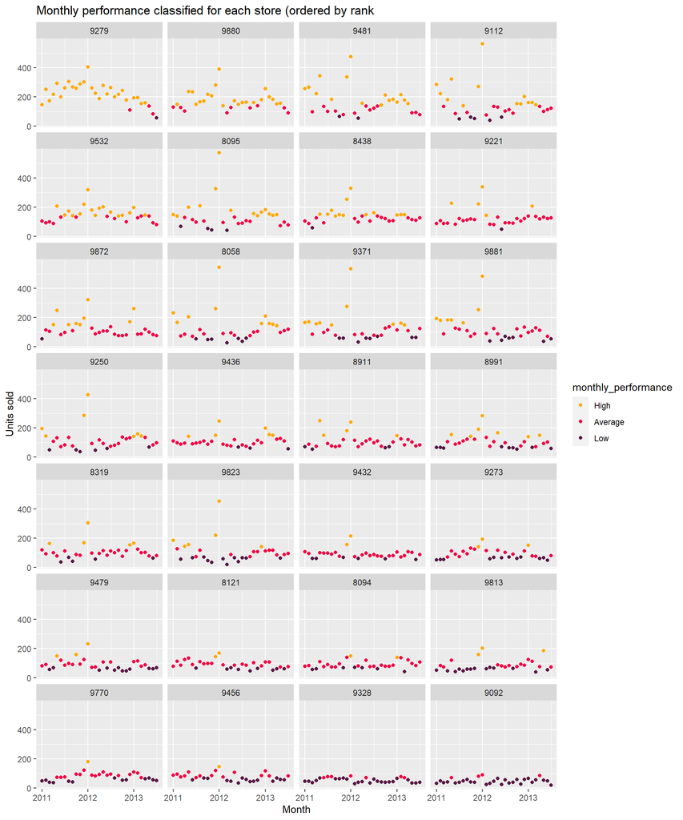

An interesting feature of these plots is that some stores have more consistent performance than others. For example store 9112 had 5 low performing months but was ranked at 4, much higher than store 9872 which had only 1 low performing month but was ranked 9. Despite having higher overall sales store 9112 was less reliably successful than store 9872.

Stores with high occurrences of low sales are not reliable and are a source of risk. As an alternative to ranking stores based on their overall sales, stores have been given a ranking based on their consistency. For every high performing month stores are given a score of 3, for every average month a score of 2 and for every low performing month a score of 1.

Below is a plot showing stores ordered according to the new consistency rank along with the number of High, Average and Low performing months they achieved. Another plot is included for comparison where stores are ranked according to overall sales. Under the new consistency ranking scheme stores with unreliable performance such as 9112 drop in rank whilst stores with reliable performance such as 9532 are ranked more highly.

Overall consistency ranking seems most appropriate for sales performance as it rewards stores with reliable monthly sales. Consistency ranking has been used to split stores into three groups of overall performance. The top third of stores (consistency rank 1-9) are evaluated as ‘High’ performing. The middle third of stores (rank 10-18) are evaluated as having ‘Average’ performance and stores in the bottom third (rank 19-28) are evaluated as ‘Low’ performing.

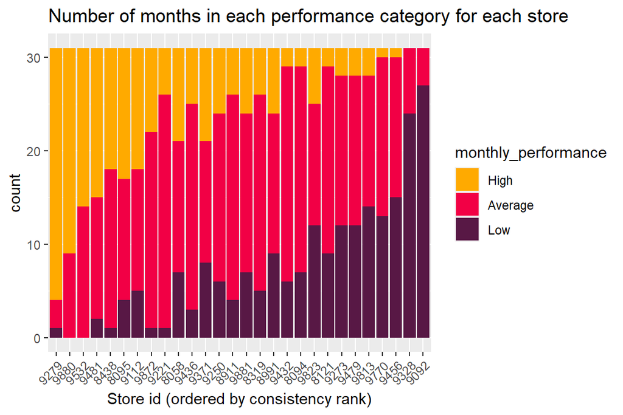

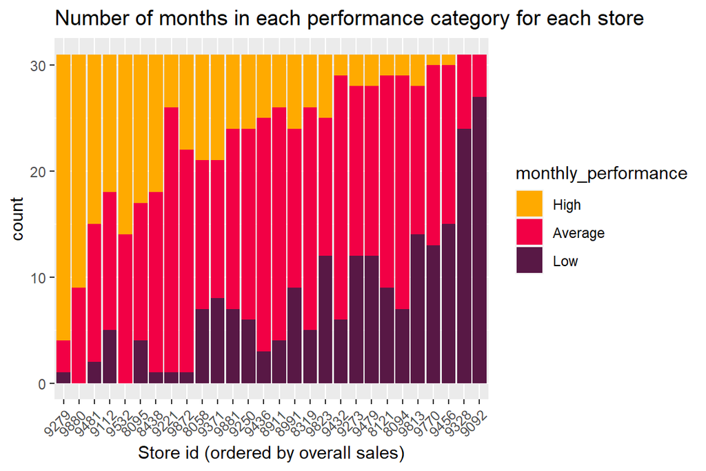

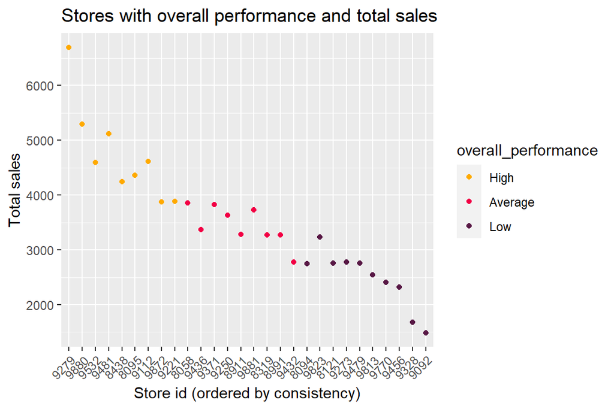

Below is a plot showing that when a product is featured and/or displayed weekly sales are more likely to be high. Weekly performance has been categorised into ‘High’, ‘Average’ and ‘Low’ based on the interquartile range of weekly sales. When the product is featured and/or displayed a higher proportion of weekly sales have been ‘High’ or ‘Average’ compared to no promotion.

Low performing stores could boost their sales by increasing the number of weeks they promote the product and unreliable stores could ensure high sales by holding regular promotions.

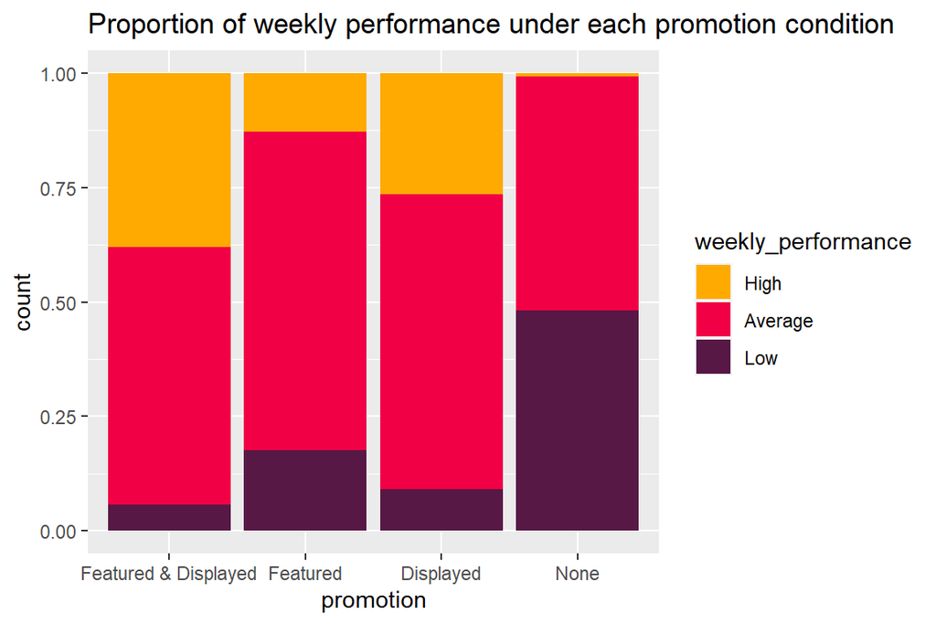

# Question 2

## (a) The Operations Manager is interested in studying an EOQ model for

```
product 216233, based on sales in 2012. The setup and holding costs
are known to be 130 per order and 1.50 per unit per year,
respectively.
```

## i) Determine the best order quantity in such a way that the costs are minimised. Write 1 – 2 paragraphs summarising your findings.

Marking criteria

• Number of orders during a year, number of days between orders, and the total annual inventory cost are correctly computed and included in the findings.

• The paragraphs clearly explain your findings.

• Assumptions of the EOQ model are clearly stated

The Economic Order Quantity (EOQ) model is used to find the best order quantity so that total costs are minimised. Key assumptions to this model are that demand is constant and known, there is no lead time, orders arrive instantaneously and back orders are not allowed. Another assumption is that stock levels are under continuous review.

Demand for product 216233 has been estimated based on the annual demand from 2012, this is 169591. The optimum order quantity is calculated based on this demand and the annual order and holding costs. The following EOQ formula is used to determine optimal order quantity where k is order cost and h is holding cost.

$$Q^* = \sqrt{\frac{2kA}{h}}$$
The optimal order quantity is calculated to be 5422 with an inventory cycle of 12 days. This means that every 12 days 5422 units are ordered, resulting in 31 annual orders. This model results in the smallest possible annual inventory cost of 8132.6803762 with an annual order cost of 4066.1803762 and an annual holding cost of 4066.5. This EOQ model is plotted for two cycles below.

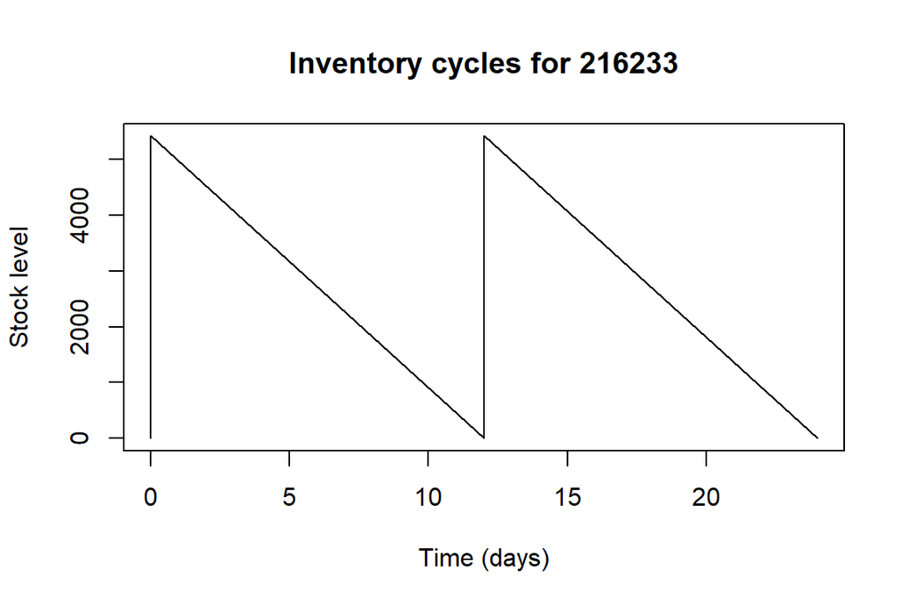

## ii) The Operations Manager is also interested in studying a model in which backorders are permitted. According to its estimates, the cost of backorders is approximately 5% of the total price (price per unit). Determine the best order quantity in the sense that inventory costs are minimised. Write 1 – 2 paragraphs summarising your findings and plot the first two inventory cycles.

• The optimum order quantity, maximum level of stock, optimum time between orders, proportion of time the company have to take backorders, and total annual inventory cost are correctly computed and included in your answer.

• The paragraphs clearly explain your findings.

• Assumptions of the model are clearly stated.

• The first two inventory cycles are correctly plotted

The Optimum Backorder Model is used to find the best order quantity so that total costs are minimised when backorders are allowed. Similar to the EOQ model assumptions are made that demand is constant and known, there is no lead time, orders arrive instantaneously and stock levels are under continuous review.

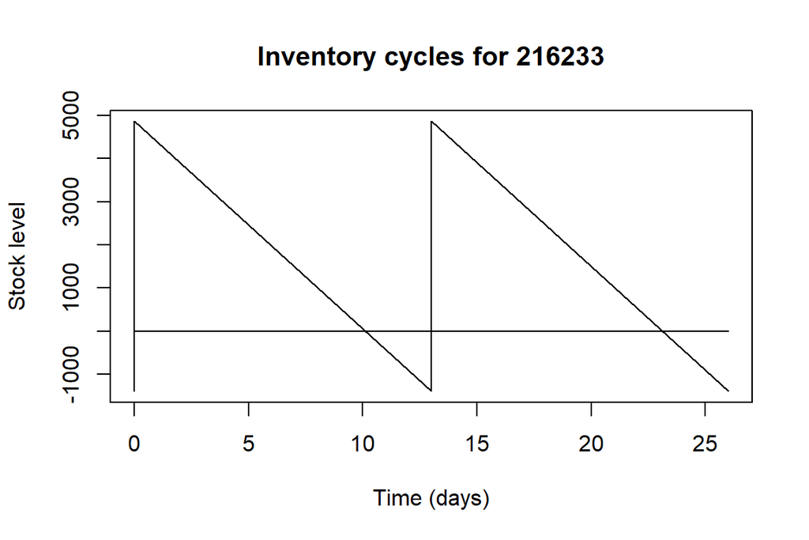

## iii) Plot the inventory cycles associated with the model in part ii and compare with the observed inventory levels in 2012, assuming actual demand during 2012, and the order frequency and order quantity from the model. Write 2 – 3 sentences describing your plot.

• The inventory levels from the model and data are correctly plotted.

• Accurate and insightful comments are made about the plot.

• Note: This is a bonus question. The maximum mark that could be awarded for this project is 100

[figure not shown]

The plot above shows the weekly demand from the 2012 sales data plotted with the optimum order frequency, 13 days and optimum order quantity 6040 from the Optimum Backorder Model. Stock starts at the optimum inventory level 4867, decreases with every weekly sale quantity from 2012 data and increases with inventory added at the optimum frequency and quantity.

Actual demand is not constant and as a result the quantity and frequency found with the back order model is not always appropriate. The model performs best when demand is constant, for example in July.

# 2b

The Operations Manager is considering the option of a multi-period inventory model. The company, as a policy, is not willing to tolerate more than 5% chance of a stock-out. The Operations Manager has estimated that the annual holding cost is 6.50 per unit and the ordering cost is 20.50 per order.

## i. Calculate a multi-period inventory model for product 216425, based on the 2012 sales data. Create plot/s of the weekly average demand of this product. Use the costs stated in part (b)above. Write a paragraph explaining the results of your model and the plot/s.

Hint: Use the weekly demand to estimate the demand during a one-week lead time.

• The optimal order quantity, safety stock, expected annual cost, orders per years are correctly computed and included in your answer.

• The paragraph clearly explains your findings.

• The assumption of normality for the demand during a one-week lead time is discussed.

• The weekly average demand of this product is correctly plotted and discussed

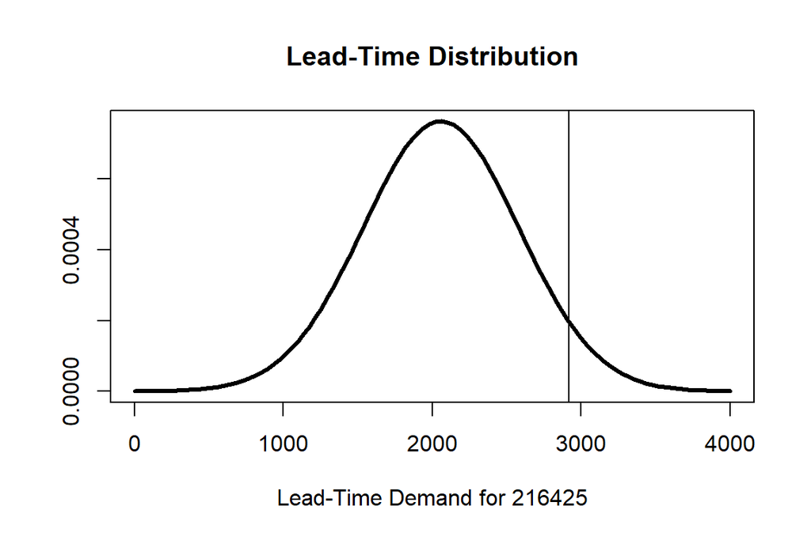

```
## integer(0)
```

For this multi-inventory model demand during a one week lead time has been estimated using the mean and standard deviation of observed data in 2012. Demand has been estimated as a normal distribution with a mean of 2057 and standard deviation of 523. As the plot below shows, whilst the actual demand for 2012 does not perfectly follow this distribution it is a adequate approximation.

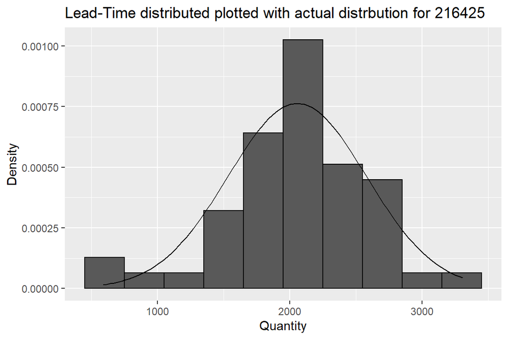

## 2.b.ii. Investigate the use of a multi-period inventory model for the product which has been assigned to your group, based on the 2012 sales data. Create plot/s of the weekly average demand of this product. Use the costs stated in part (b) above.

## Discuss the assumptions of the model and suggest a solution, in case of finding any problems. Write a paragraph explaining the results of your findings and the plot.

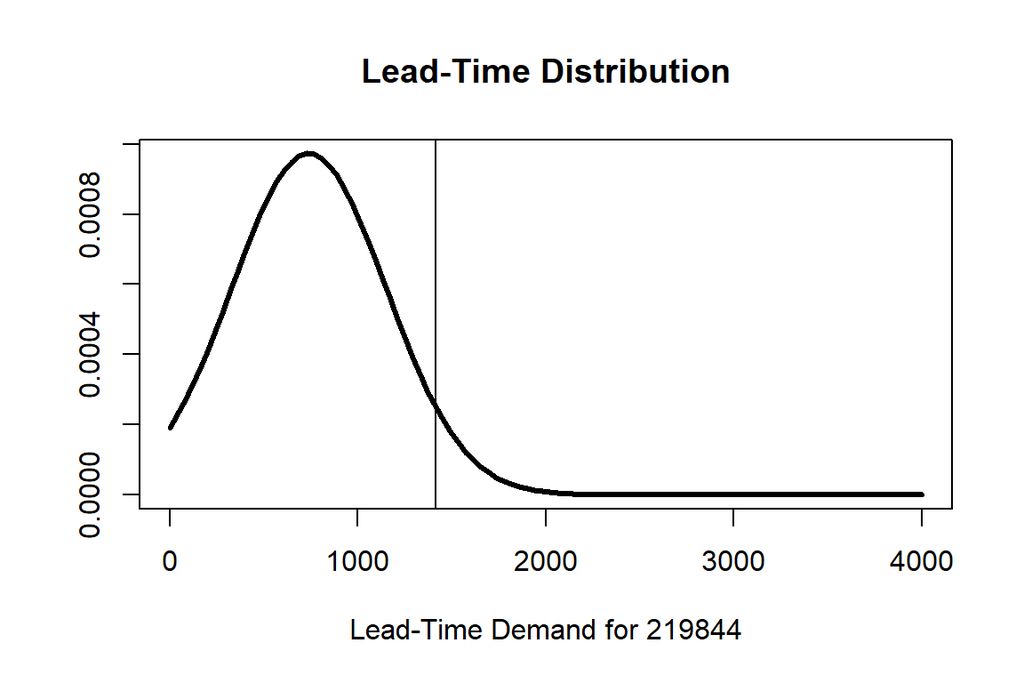

```
## integer(0)
```

For this multi-inventory model demand during a one week lead time has been estimated using the mean and standard deviation of observed data in 2012. Demand has been estimated as a normal distribution with a mean of 739 and standard deviation of 410. As the plot below shows this distribution is a very poor fit for the observed data. It is recommended that a more accurate distribution is used for estimating the Lead-Time distribution and reorder point. It is likely that the reorder point calculated with this normal distribution is unnecessarily high.

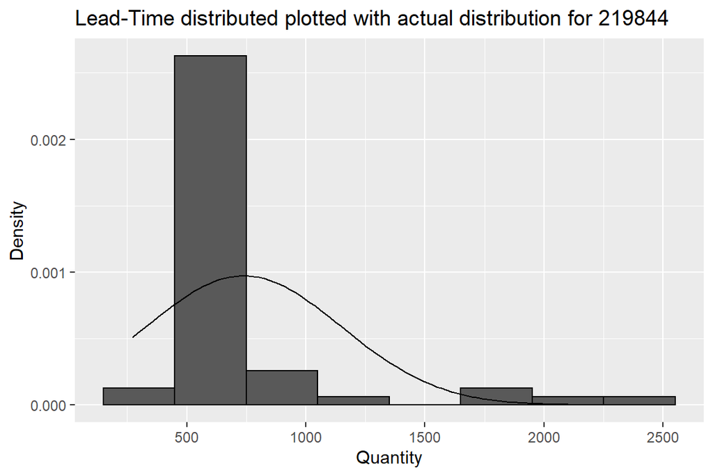

# Question 3

## a) For the product (asin) that has been assigned to your group, use summary statistics and plots to analyse the overall review rating (overall). Write a paragraph describing your findings to the General Manager - sales.

Marking Criteria • Summary statistics for the overall review rating have been correctly computed and are displayed in appropriate plot/s.

• Descriptions of results and plots are correct and provide useful insights.

• Plot/s are constructed using ggplot2 and have appropriate titles,labels,scalesetc.

## Answer

Reviews were rated from 1-5. The mean rating for product B00006IE7J is 4.6692308. Most reviews were rated highly with 79 given 5 and 13.4 given 4 stars.

[output not shown]

Some reviews were verified and others were not. The proportion of ratings given by these different groups are compared below. The unverified group gave a higher proportion of ratings 2-4 than the verified group.

Review ratings have been plotted below against time. Most reviews were given between 2014 and 2018. Rating does not appear to be strongly correlated with time.

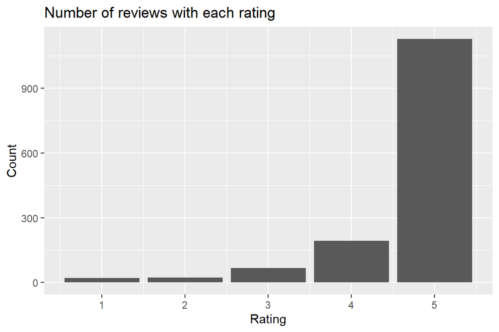

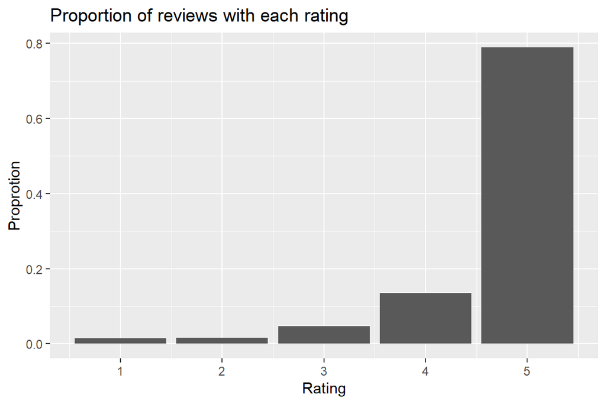

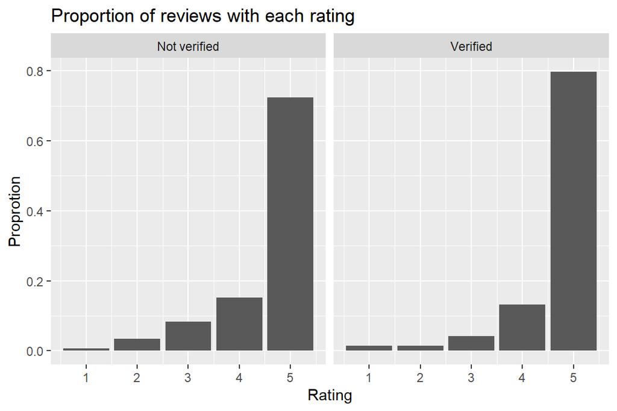

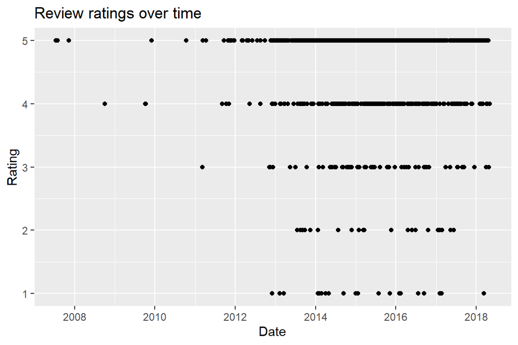

## Question 3b

## Using the review text (reviewText) and any other variables you think are relevant, investigate the customer sentiment towards, and satisfaction/dissatisfaction with, the product that has been assigned to your group. Your answer should include a word cloud and a sentiment analysis.

• Appropriate methods are used to tidy the text data.

• Correctly construct and interpret a word cloud of the reviewText variable.

• Correctly perform and interpret a sentiment analysis of the reviewText variable.

• Correctly perform and interpret some additional analysis of the reviewText variable, incorporating at least one other variable from the dataset.

• Interpretations of analyses are correct, provide insight and are written at an appropriate level for a manager.

## Answer

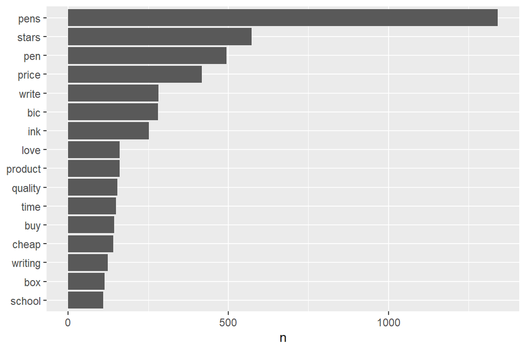

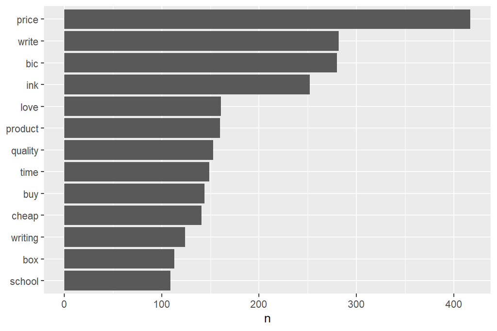

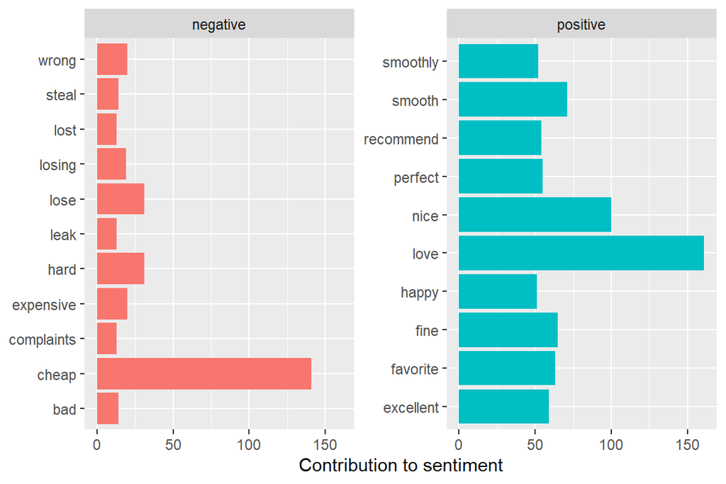

Using tidytext, going to tidy the data. First, we select the rows we want to use for the sentiment analysis

```
## # A tibble: 6 x 6
##   document.id overall verified reviewText             summary         date
##         <int>   <int> <lgl>    <chr>                  <chr>           <date>
## 1       48735       4 TRUE     Good quality bulk pen~ Four Stars      2018-05-01
## 2       48762       3 TRUE     I bought six boxes, f~ five boxes are~ 2018-04-24
## 3       48763       5 TRUE     These pens consistent~ consistently w~ 2018-04-22
## 4       48774       5 TRUE     They're pens. What el~ Cheap Price fo~ 2018-04-21
## 5       48775       5 TRUE     Good Good              Five Stars      2018-04-16
## 6       48776       4 TRUE     Classic pen.  Average~ Good Deal       2018-04-10
```

We clean the data by using `unnest_tokens` to tokenize the `reviewText` column. We also add a column representing the line number for the data

```
## # A tibble: 6 x 7
##   document.id overall verified summary    date       reviewWord linenumber
##         <int>   <int> <lgl>    <chr>      <date>     <chr>           <int>
## 1       48735       4 TRUE     Four Stars 2018-05-01 good                1
## 2       48735       4 TRUE     Four Stars 2018-05-01 quality             2
## 3       48735       4 TRUE     Four Stars 2018-05-01 bulk                3
## 4       48735       4 TRUE     Four Stars 2018-05-01 pens                4
## 5       48735       4 TRUE     Four Stars 2018-05-01 especially          5
## 6       48735       4 TRUE     Four Stars 2018-05-01 for                 6
```

Now, we remove the stop words. Our stop words are taken from the `stop_words` dataset included in tidytext. By using an anti_join, we are able to filter out the stop words.

Below, we plot the words in the cleaned dataset, according to the number of times they are present in the dataset.

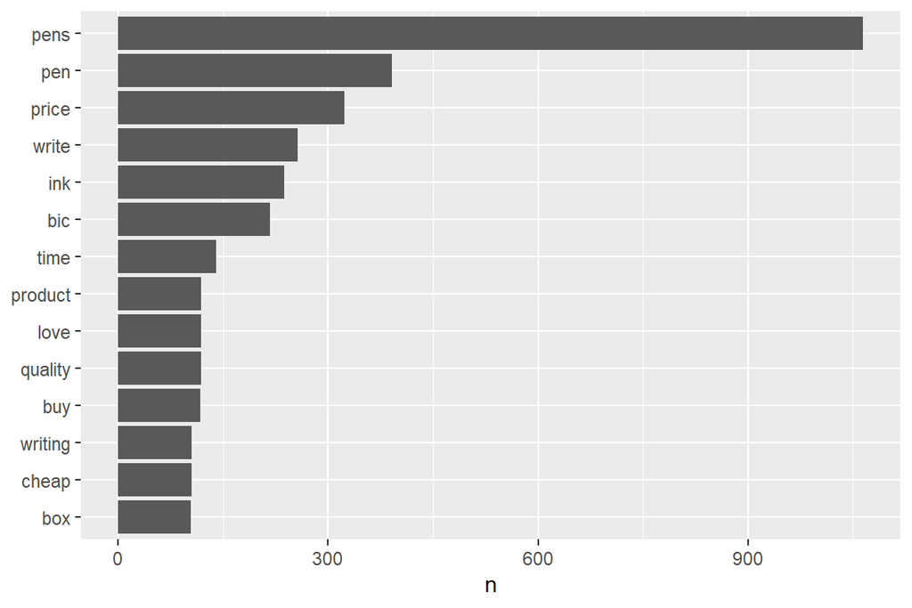

On an initial analysis, we can see that the word `pen(s)` has been used the most. Since this word describes our product, it is used quite often in the reviews. After that, customers mention the price of the item a lot more than any thing else. The rest of the words are used to describe the product and it’s features.

```
## # A tibble: 6 x 6
##   document.id overall negative positive sentiment linenumber
##         <int>   <int>    <dbl>    <dbl>     <dbl>      <int>
## 1       48762       3        1        0        -1          1
## 2       48763       5        0        1         1          2
## 3       48774       5        0        2         2          3
## 4       48776       4        0        1         1          4
## 5       48803       5        0        2         2          5
## 6       48837       5        1        2         1          6
```

The mean sentiment of all reviews is 0.7593261.

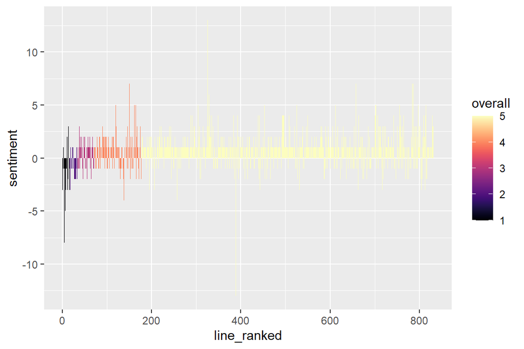

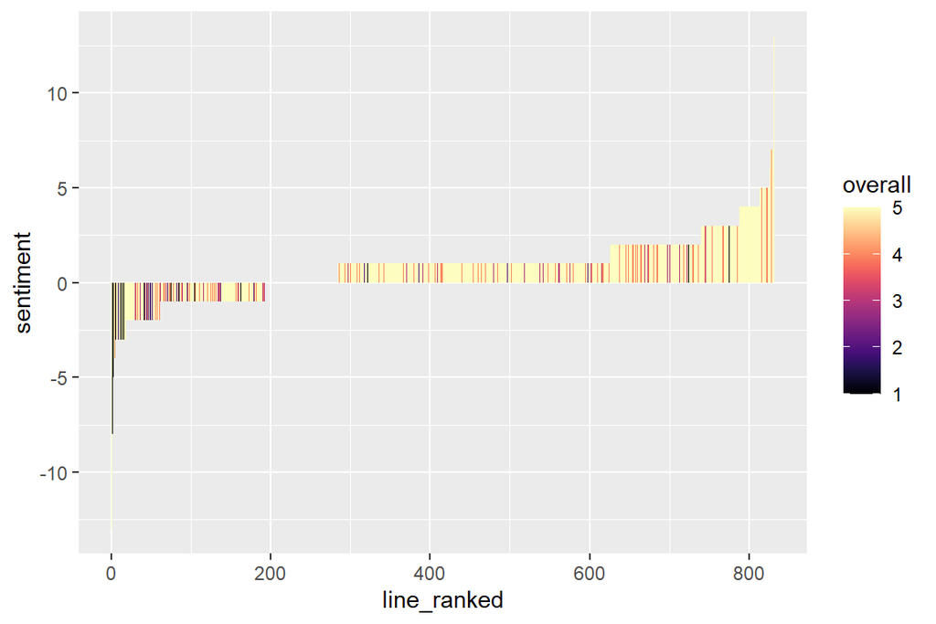

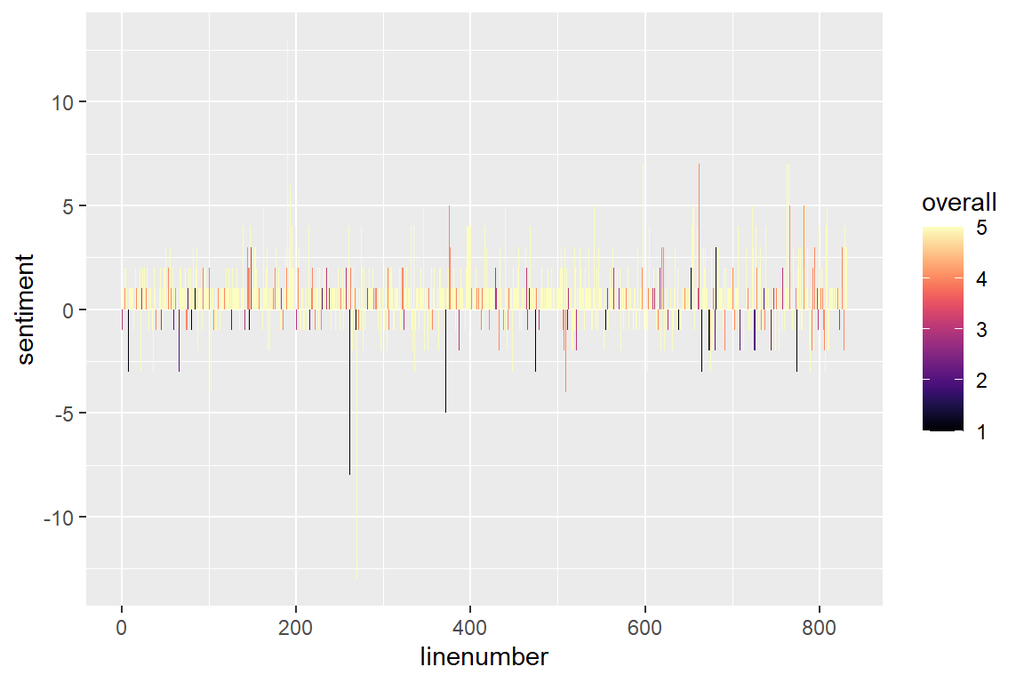

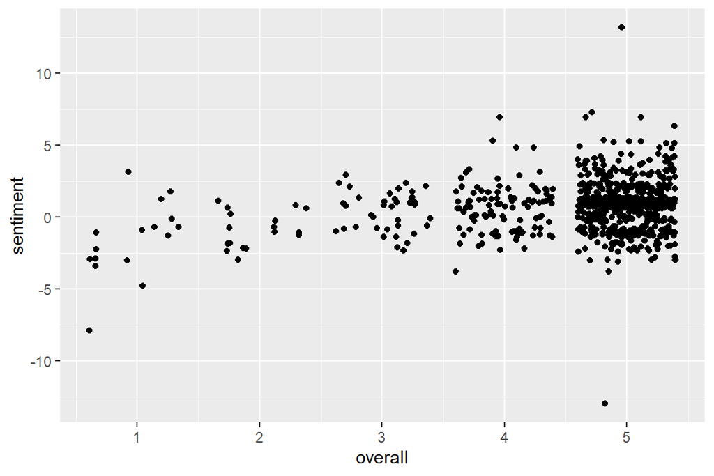

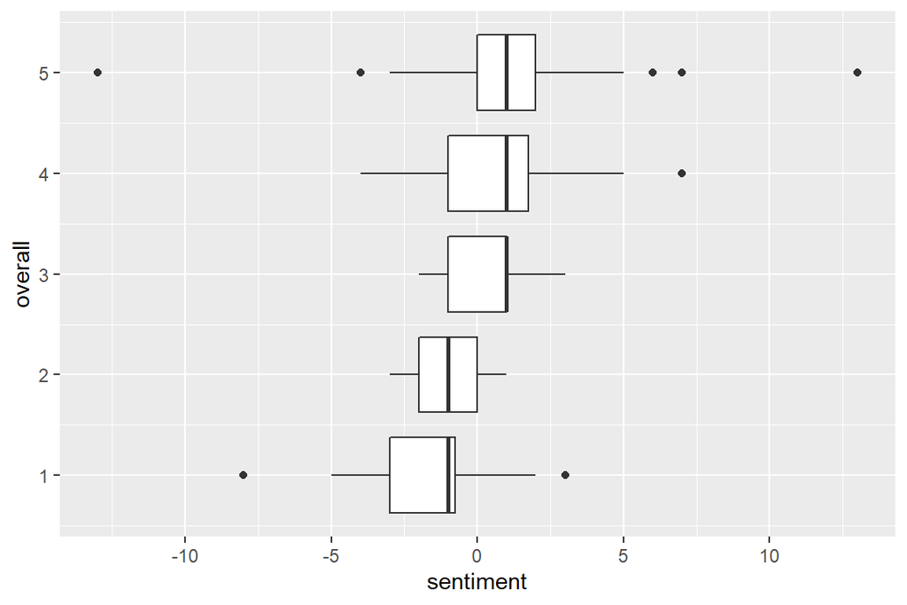